# projekt_teoria_portfela_stanisz

```python
# Projekt: Teoria portfela
# Autor: Przemyslaw Stanisz

# Ladujemy biblioteki
import pandas as pd
import random as rn
import numpy as np
import matplotlib.pyplot as plt
from numpy.linalg import inv
%matplotlib inline
plt.rcParams['figure.figsize'] = [10, 10]
```

Klucz dzięki któremu wygenerujemy, które spółki będziemy analizować

```python
KLUCZ = {'RR': 85, 'MM': 11, 'DD': 13, 'RM': 51, 'MD': 11}
reszty = [x % 20 for x in  KLUCZ.values()]
```

```python
reszty = list(set(reszty))
print(reszty)
```

```
[13, 11, 5]
```

Okazuje się że dwie spółki się powtórzyły. Wygenerujemy sobie dwie kolejne.

```python
rn.seed(3)

while len(reszty) < 5:
 n = rn.randint(1,20)
 if n in reszty:
     continue
 else:
     reszty.append(n)
```

W końcu mamy nasze pięć spółek.

```python
print(reszty)
```

```
[13, 11, 5, 8, 19]
```

Przygotowałem (tak na przyszłość) listę wszystkich spółek z WIG20

```python
'''
 0 - AliorBank,        'https://stooq.pl/q/d/l/?s=alr'
 1 - CCC,              'https://stooq.pl/q/d/l/?s=ccc'
 2 - CDProjekt,        'https://stooq.pl/q/d/l/?s=cdr'
 3 - CyfrowyPolsat,    'https://stooq.pl/q/d/l/?s=cps'
 4 - Energa,           'https://stooq.pl/q/d/l/?s=eng'
 5 - EuroCash,         'https://stooq.pl/q/d/l/?s=eur'
 6 - JSW,              'https://stooq.pl/q/d/l/?s=jsw'
 7 - KGHM,             'https://stooq.pl/q/d/l/?s=kgh'
 8 - Lotos,            'https://stooq.pl/q/d/l/?s=lts'
 9 - LPP,              'https://stooq.pl/q/d/l/?s=lpp'
10 - MBank,            'https://stooq.pl/q/d/l/?s=mbk'
11 - OrangePL,         'https://stooq.pl/q/d/l/?s=opl'
12 - PeKaO S.A.,       'https://stooq.pl/q/d/l/?s=peo'
13 - PGE,              'https://stooq.pl/q/d/l/?s=pge'
14 - PGNiG,            'https://stooq.pl/q/d/l/?s=pgn'
15 - PKN Orlen,        'https://stooq.pl/q/d/l/?s=pkn'
16 - PKO BP,           'https://stooq.pl/q/d/l/?s=pko'
17 - PZU,              'https://stooq.pl/q/d/l/?s=pzu'
18 - SandanderPl,      'https://stooq.pl/q/d/l/?s=spl'
19 - Tauron.           'https://stooq.pl/q/d/l/?s=tpe'
'''
adresy_wig = [
    r'https://stooq.pl/q/d/l/?s=alr&i=w&o',
    r'https://stooq.pl/q/d/l/?s=ccc&i=w&o',
    r'https://stooq.pl/q/d/l/?s=cdr&i=w&o',
    r'https://stooq.pl/q/d/l/?s=cps&i=w&o',
    r'https://stooq.pl/q/d/l/?s=eng&i=w&o',
    r'https://stooq.pl/q/d/l/?s=eur&i=w&o',
    r'https://stooq.pl/q/d/l/?s=jsw&i=w&o',
    r'https://stooq.pl/q/d/l/?s=kgh&i=w&o',
    r'https://stooq.pl/q/d/l/?s=lts&i=w&o',
    r'https://stooq.pl/q/d/l/?s=lpp&i=w&o',
    r'https://stooq.pl/q/d/l/?s=mbk&i=w&o',
    r'https://stooq.pl/q/d/l/?s=opl&i=w&o',
    r'https://stooq.pl/q/d/l/?s=peo&i=w&o',
    r'https://stooq.pl/q/d/l/?s=pge&i=w&o',
    r'https://stooq.pl/q/d/l/?s=pgn&i=w&o',
    r'https://stooq.pl/q/d/l/?s=pkn&i=w&o',
    r'https://stooq.pl/q/d/l/?s=pko&i=w&o',
    r'https://stooq.pl/q/d/l/?s=pzu&i=w&o',
    r'https://stooq.pl/q/d/l/?s=spl&i=w&o',
    r'https://stooq.pl/q/d/l/?s=tpe&i=w&o']


WIG20 = [ 'AliorBank','CCC','CDProjekt', 'CyfrowyPolsat', 'Energa', 'EuroCash', 'JSW', 'KGHM', 'Lotos',
          'LPP', 'MBank', 'OrangePL', 'PeKaO S.A.', 'PGE', 'PGNiG', 'PKN Orlen', 'PKO BP', 'PZU', 'SandanderPl',
          'Tauron']
```

W końcu możemy pobrać moje 'wylosowane' spółki.

```python
data1 = pd.read_csv(adresy_wig[reszty[0]])
data2 = pd.read_csv(adresy_wig[reszty[1]])
data3 = pd.read_csv(adresy_wig[reszty[2]])
data4 = pd.read_csv(adresy_wig[reszty[3]])
data5 = pd.read_csv(adresy_wig[reszty[4]])

for i in reszty:
    print(WIG20[i])
```

```
PGE
OrangePL
EuroCash
Lotos
Tauron
```

Tak będą się przedstawiać przykładowe dane...

```python
# Przykładowe dane
data3.describe()
```

|  | Otwarcie | Najwyzszy | Najnizszy | Zamkniecie | Wolumen |
| --- | --- | --- | --- | --- | --- |
| count | 754.000000 | 754.000000 | 754.000000 | 754.000000 | 7.540000e+02 |
| mean | 22.437012 | 23.251620 | 21.536374 | 22.438318 | 1.634695e+06 |
| std | 13.803985 | 14.303577 | 13.224919 | 13.772039 | 1.580295e+06 |
| min | 2.311700 | 2.360000 | 2.231000 | 2.319600 | 1.052500e+04 |
| 25% | 8.284000 | 8.609125 | 7.919525 | 8.308100 | 5.460015e+05 |
| 50% | 21.849500 | 22.310500 | 20.939000 | 21.702000 | 1.178192e+06 |
| 75% | 33.430750 | 34.626000 | 32.272500 | 33.386750 | 2.185624e+06 |
| max | 54.411000 | 56.351000 | 52.356000 | 54.793000 | 1.222607e+07 |

...oraz pierwsze 10 wierszy

```python
data3.head(10)
```

|  | Data | Otwarcie | Najwyzszy | Najnizszy | Zamkniecie | Wolumen |
| --- | --- | --- | --- | --- | --- | --- |
| 0 | 2005-02-06 | 2.3117 | 2.4324 | 2.3117 | 2.3761 | 9764629 |
| 1 | 2005-02-13 | 2.3761 | 2.4647 | 2.3279 | 2.4324 | 5281883 |
| 2 | 2005-02-20 | 2.4003 | 2.4405 | 2.3279 | 2.3841 | 1472074 |
| 3 | 2005-02-27 | 2.3922 | 2.4163 | 2.2955 | 2.4003 | 1489762 |
| 4 | 2005-03-06 | 2.4003 | 2.4003 | 2.3196 | 2.3600 | 341856 |
| 5 | 2005-03-13 | 2.3600 | 2.3841 | 2.3279 | 2.3680 | 486964 |
| 6 | 2005-03-20 | 2.3680 | 2.3680 | 2.2310 | 2.3438 | 551406 |
| 7 | 2005-03-27 | 2.3438 | 2.3600 | 2.2310 | 2.3196 | 861807 |
| 8 | 2005-04-03 | 2.3438 | 2.4003 | 2.3196 | 2.3680 | 1077013 |
| 9 | 2005-04-10 | 2.3761 | 2.5855 | 2.3519 | 2.5132 | 1115682 |

Zadanie wymagało przeanalizowania ostatnich 52 tygodni:

```python
data1 = data1[-52:]
data1 = data1.reset_index(drop=True)
data2 = data2[-52:]
data2 = data2.reset_index(drop=True)
data3 = data3[-52:]
data3 = data3.reset_index(drop=True)
data4 = data4[-52:]
data4 = data4.reset_index(drop=True)
data5 = data5[-52:]
data5 = data5.reset_index(drop=True)
```

Upewniam się czy tak jest (indeksowanie jest od zera)

```python
data3.tail()
```

|  | Data | Otwarcie | Najwyzszy | Najnizszy | Zamkniecie | Wolumen |
| --- | --- | --- | --- | --- | --- | --- |
| 47 | 2019-06-16 | 20.60 | 20.78 | 19.55 | 20.36 | 1043374 |
| 48 | 2019-06-23 | 20.38 | 20.78 | 19.64 | 19.94 | 759766 |
| 49 | 2019-06-30 | 20.10 | 20.98 | 19.12 | 20.60 | 935681 |
| 50 | 2019-07-07 | 20.60 | 20.92 | 19.68 | 20.00 | 609131 |
| 51 | 2019-07-14 | 20.02 | 20.18 | 19.50 | 19.65 | 1111246 |

```python
# funkcja licząca tygodniwe zwroty
def DataToWeekReturn(data):
    return [0]+[(data["Zamkniecie"][i+1]-data["Zamkniecie"][i])/data["Zamkniecie"][i] for i in range(len(data)-1)]
```

## Tygodniowe zwroty

Obliczam tygodniowe zwroty dla każdej spółki przy pomocy wcześniej zdefinowanej funkcji. Do utworzonej 'ramki' dodaje nową kolumnę 'Returns'.

```python
data1['Returns'] = DataToWeekReturn(data1)
data2['Returns'] = DataToWeekReturn(data2)
data3['Returns'] = DataToWeekReturn(data3)
data4['Returns'] = DataToWeekReturn(data4)
data5['Returns'] = DataToWeekReturn(data5)
```

## Vector $\mu$

Tworzę wektor zawierający średnie tygodniowe zwroty.

```python
mu = [data1['Returns'].mean(), data2['Returns'].mean(), data3['Returns'].mean(), data4['Returns'].mean(), data5['Returns'].mean()]

for row in mu:
    print(f'{row:8.5f}')
```

```
 0.00116
 0.00847
 0.00252
 0.00865
-0.00101
```

## Covariance Matrix C

Tworzę macierz covariancji. Tutaj posługuję się wbudowaną funkcją biblioteki 'numpy'.

```python
C = np.cov([data1['Returns'], data2['Returns'], data3['Returns'], data4['Returns'], data5['Returns']])

for row in C:
    for val in row:
        print(f'{val:8.5f}', end=' ')
    print()
```

```
 0.00199  0.00010 -0.00001  0.00014  0.00127
 0.00010  0.00258  0.00059  0.00030  0.00022
-0.00001  0.00059  0.00310 -0.00050 -0.00033
 0.00014  0.00030 -0.00050  0.00180  0.00008
 0.00127  0.00022 -0.00033  0.00008  0.00214
```

#### Na piechotę

Ale jakbyśmy chcieli to taką macierze bez problemu policzymy też definiując własną funkcję.

```python
def convar(X, Y):
    # TODO add if they have the same length
    Xmean = X.mean()
    Ymean = Y.mean()
    Sum = 0.0
    N = len(X)
    for i in range(N):
        Sum += (Xmean - X[i])*(Ymean - Y[i])

    return Sum/(N-1)

def correl(X, Y):
    # TODO add if they have the same length
    Xmean = X.mean()
    Ymean = Y.mean()
    Sum = 0.0
    N = len(X)
    for i in range(N):
        Sum += (Xmean - X[i])*(Ymean - Y[i])

    return (Sum/(X.var()*Y.var())**0.5)/(N-1)
```

```python
D = [data1['Returns'], data2['Returns'], data3['Returns'], data4['Returns'], data5['Returns']]
# W tym momencie tworzymy macierz, korzystając z funkcji liczącą covariancje
D = [[convar(x,y) for y in D] for x in D]


for row in D:
    for val in row:
        print(f'{val:8.5f}', end=' ')
    print()
```

```
 0.00199  0.00010 -0.00001  0.00014  0.00127
 0.00010  0.00258  0.00059  0.00030  0.00022
-0.00001  0.00059  0.00310 -0.00050 -0.00033
 0.00014  0.00030 -0.00050  0.00180  0.00008
 0.00127  0.00022 -0.00033  0.00008  0.00214
```

Tworzę wektor wag. Inicjując go równo wagowymi wartościami.

```python
nb = len(reszty)
w = np.matrix([1/5 for i in range(nb)])

print(w)
```

```
[[0.2 0.2 0.2 0.2 0.2]]
```

Oczywiście, na diagonali będą znajdować się wariancje dla naszych spółek.

```python
# na piechotę
V = []
for i in range(len(D)):
    for j in range(len(D[i])):
        if i == j:
            V.append(D[i][j])

print(V)

# bądź z pomocą biblioteki
print(np.diag(C))
```

```
[0.00198503426922724, 0.0025768803858518844, 0.003097095480694532, 0.0018001568917724664, 0.0021427925932162887]
[0.00198503 0.00257688 0.0030971  0.00180016 0.00214279]
```

## Wprowadzenie do zadan

Wariancje portfela o zadanych wagach w, policzymy w sposób następujący:

```python
print(np.asscalar(w*C*w.T))
```

```
0.0006113897873187905
```

A zwrot portfela policzymy z pomnożenia każdego zwrotu akcji przez wagę portfela:

```python
mu = np.matrix(mu)
print(np.asscalar(w*mu.T)) # mu portfela
```

```
0.003956305783438282
```

Wprowadźmy jeszcze Wektr jednostkowy **I** i macierz **M** potrzebną do metody mnożników Lagrange'a

```python
I = np.matrix(np.ones(nb))
M = np.matrix([[np.asscalar(mu  * inv(C) * mu.T) ,  np.asscalar(I * inv(C) * mu.T)],
               [np.asscalar(mu  * inv(C) * I.T)  ,  np.asscalar(I * inv(C) * I.T)]])
print(I)
print(M)
```

```
[[1. 1. 1. 1. 1.]]
[[6.69258063e-02 7.79219158e+00]
 [7.79219158e+00 1.80223906e+03]]
```

Wykorzystujemy zdefiniowane m i odwrotną macierz **M** do wyliczenia lambdy i gammy

$\begin{bmatrix} \lambda\\ \gamma \end{bmatrix} = M^{-1} \begin{bmatrix} m\\ 1 \end{bmatrix}$

a następnie wyliczenia wektora **w**

$ w = \lambda C^{-1} \mu + \gamma C^{-1} \boldsymbol 1$

i ostatecznie wariancji i niepewności dla tego wektora:

$w^{T}\cdot C \cdot w$

```python
m = np.linspace(-0.02, 0.05, 50) # start, stop, ile punktów
g =[]
for i in m:
    lambda_gama = inv(M) * np.matrix([i,1]).T
    w = np.asscalar(lambda_gama[0]) * inv(C) * mu.T + np.asscalar(lambda_gama[1]) * inv(C) * I.T
    g.append( np.asscalar(w.T*C*w)**0.5)
g = np.array(g)
```

Moge w końcu dla liniowo zmieniającego się wektora wejściowego odpowiadającemu zwrot portfela narysować krzywą dla portfeli o najmniejszej wariancji (co *de facto* jest tematem **zadania 3**).

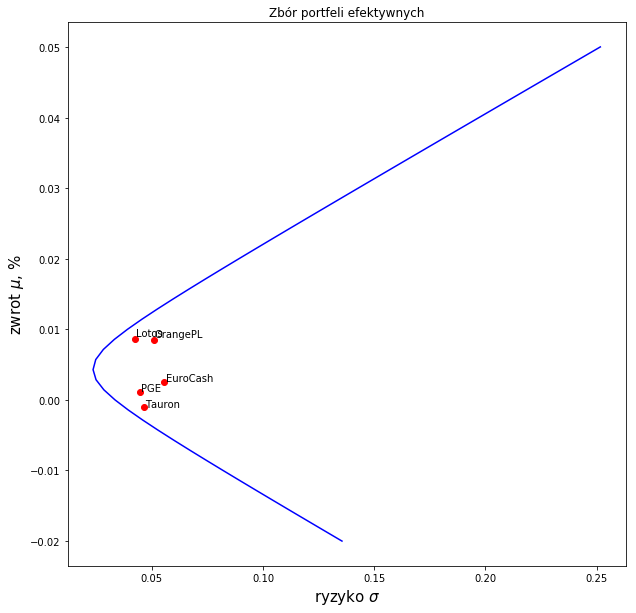

```python
# simulating a pandas df['type'] column
types = [WIG20[i] for i in reszty]
x_coords = np.diagonal(C)**0.5
y_coords = np.array(mu)[0]

for i,type in enumerate(types):
    x = x_coords[i]
    y = y_coords[i]
    plt.scatter(x, y, marker='o', color='red')
    plt.text(x+x*0.01, y+y*0.05, type, fontsize=10)
plt.plot(g, m, 'b')
plt.title('Zbór portfeli efektywnych')
plt.xlabel(r'ryzyko $\sigma$', fontsize=15)
plt.ylabel(r'zwrot $\mu$, %', fontsize=15)
plt.show()
```

# Zadanie 1

*Portfel o minimalnej wariancji*

Wagi portfela o minimalnej wariancji policzymy za pomocą formuły:

$w_{min} = \frac{C^{-1}\boldsymbol 1}{\boldsymbol 1^T C^{-1} \boldsymbol 1}$

```python
w = (inv(C)*I.T)/(I*inv(C)*I.T)
```

```python
print(w)

# sprawdzenie czy suma jest równa 1.
print(w.sum())
```

```
[[0.12576548]
 [0.10077963]
 [0.23671445]
 [0.33865999]
 [0.19808046]]
1.0
```

Dla tego portfela od razu przeliczam Zwrot i ryzyko:

```python
print(f"Warjancja dla portfela {np.asscalar(w.T*C*w):7.5f}") # variancja portfela
print(f"Zwrot dla portfela o minimalnej wariancji {np.asscalar(w.T*mu.T):7.5f}") # mu portfela
```

```
Warjancja dla portfela 0.00055
Zwrot dla portfela o minimalnej wariancji 0.00432
```

Teraz tylko pozostaje nanieść portfel na krzywą portfeli o najmniejszej wariancji.

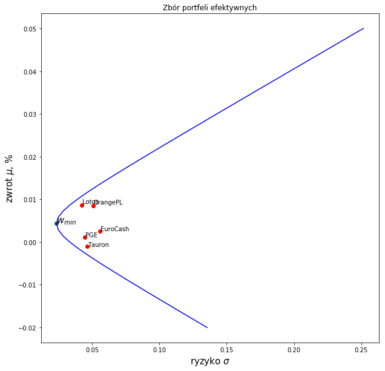

```python
types = [WIG20[i] for i in reszty]
x_coords = np.diagonal(C)**0.5
y_coords = np.array(mu)[0]

for i,typ in enumerate(types):
    x = x_coords[i]
    y = y_coords[i]
    plt.scatter(x, y, marker='o', color='red')
    plt.text(x+x*0.01, y+y*0.05, typ, fontsize=10)

x = np.asscalar(w.T*C*w)**0.5
y = np.asscalar(w.T*mu.T)
plt.scatter(x, y, marker='o', color='green')
plt.text(x, y*1.05, r'$w_{min}$', fontsize=15)
plt.plot(g, m, 'b')
plt.title('Zbór portfeli efektywnych')
plt.xlabel(r'ryzyko $\sigma$', fontsize=15)
plt.ylabel(r'zwrot $\mu$, %', fontsize=15)
plt.show()
```

# Zadanie 2

*Zakladajac r = 0% (stopa wolna od ryzyka) Wyznaczamy portfel rynkowy*

Portfel rynkowy znajdujemy z formuły: $ w = \frac{C^{-1}(\mu - r \boldsymbol 1 )}{\boldsymbol 1^T C^{-1}(\mu - r \boldsymbol 1)}$

```python
m = np.linspace(-0.02, 0.05, 50) # start, stop, ile punktów
r = 0.0 # stopa wolna od ryzyka


# wagi portfela rynkowego
w2 =  (inv(C) * (mu.T - r * I.T)) / (I * inv(C) * (mu.T - r * I.T))
print(w2)
sig_m = np.asscalar(w2.T*C*w2)**0.5
mu_m = np.asscalar(w2.T*mu.T)
```

```
[[ 0.13178154]
 [ 0.33579995]
 [ 0.11802404]
 [ 0.59145808]
 [-0.1770636 ]]
```

Portfel rynkowy jak i prostą zawierającą możliwe do zbódowania portfele pośrednie w oparciu o wolny walor zaznaczama na płaszcyźnie *zysk-ryzyko*

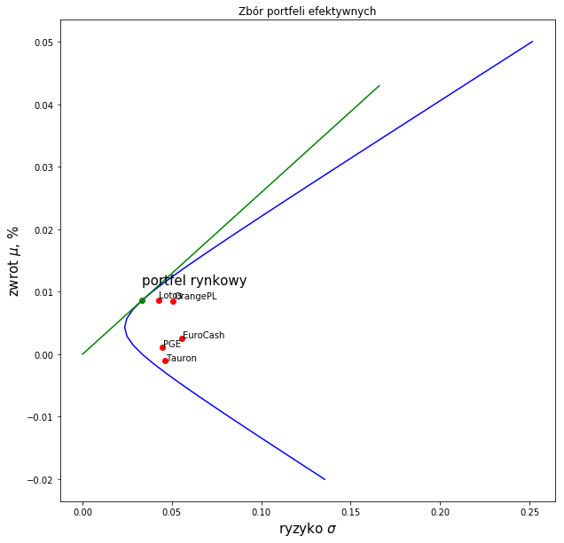

```python
types = [WIG20[i] for i in reszty]
x_coords = np.diagonal(C)**0.5
y_coords = np.array(mu)[0]

for i,typ in enumerate(types):
    x = x_coords[i]
    y = y_coords[i]
    plt.scatter(x, y, marker='o', color='red')
    plt.text(x+x*0.01, y+y*0.05, typ, fontsize=10)

plt.plot(g, m, 'b')
plt.plot([0.0, sig_m, 5*sig_m], [r, mu_m, 5*mu_m-r], 'g')
plt.plot(sig_m, mu_m, 'og')
plt.text(sig_m, mu_m*1.3, r'portfel rynkowy', fontsize=15)
plt.title('Zbór portfeli efektywnych')
plt.xlabel(r'ryzyko $\sigma$', fontsize=15)
plt.ylabel(r'zwrot $\mu$, %', fontsize=15)
plt.show()
```

# Zadanie 4

*Obliczyć bety dla kazdej spółki*

Dla obliczenia bet mogę użyć dowolnie zdefiniowanego wektora wag.  
Dla prezentacji zakładam że będą to wago dla portfela rynkowego.

```python
w2 =  (inv(C) * (mu.T - r * I.T)) / (I * inv(C) * (mu.T - r * I.T))
print(w2)
```

```
[[ 0.13178154]
 [ 0.33579995]
 [ 0.11802404]
 [ 0.59145808]
 [-0.1770636 ]]
```

Obliczam zwroty dla portfela.

```python
# obliczmy zwroty dla portfela:
data0 = pd.DataFrame(data1['Returns']*np.asscalar(w2[0]) +
                     data2['Returns']*np.asscalar(w2[1]) +
                     data3['Returns']*np.asscalar(w2[2]) +
                     data4['Returns']*np.asscalar(w2[3]) +
                     data5['Returns']*np.asscalar(w2[4]),
                     columns = ['Returns'] )
```

Możemy zobaczyć jak zwroty z poszczególnych spółek mają się do zwrotu z portfela.

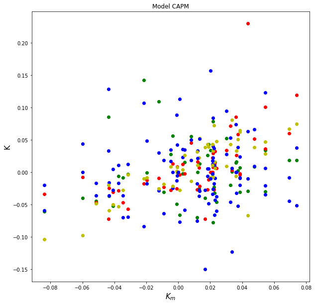

```python
plt.plot(data0['Returns'], data1['Returns'], 'og')
plt.plot(data0['Returns'], data2['Returns'], 'or')
plt.plot(data0['Returns'], data3['Returns'], 'ob')
plt.plot(data0['Returns'], data4['Returns'], 'oy')
plt.plot(data0['Returns'], data5['Returns'], 'ob')

plt.title('Model CAPM')
plt.xlabel(r'$K_m$', fontsize=15)
plt.ylabel(r'K', fontsize=15)
plt.show()
```

Potrzebujemy policzyć najlepiej dopasowaną prostą do danych.  
Do tego zadania skorzystałem z kolejnej biblioteki zawierającej funkcje potrzebnej do wyliczenia współczynników liniowych dla metody najmniejszych kwadratów.

Przykładowy sposów postępowania jest prezentowany da spółki nr 2. (w moim przypadku jest to Orange). Na koniec wszystkie współczynniki zostały policzone.

```python
import numpy as np
from sklearn.linear_model import LinearRegression

model = LinearRegression().fit(np.array(data0['Returns']).reshape((-1,1)), data2['Returns'])
```

```python
x = np.linspace(-0.08, 0.08, 20).reshape((-1,1)) # zakres w jakim będę uzyskiwał punkty.
y = model.predict(x)
```

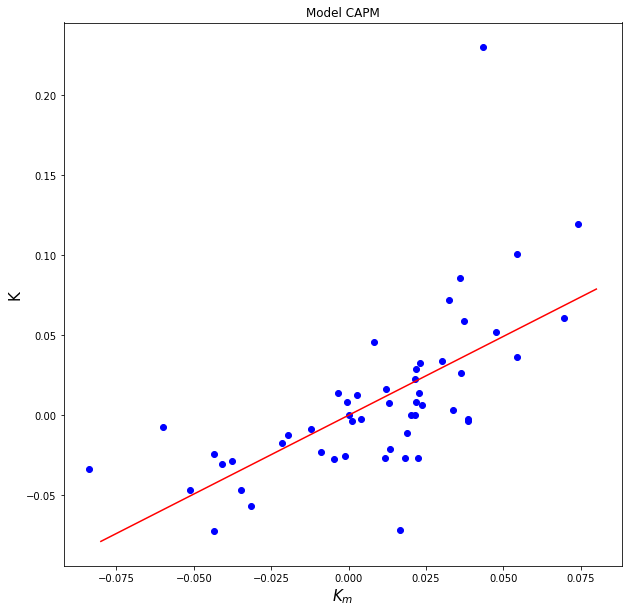

```python
plt.plot(data0['Returns'], data2['Returns'], 'ob')
plt.plot(x, y, 'r')

plt.title('Model CAPM')
plt.xlabel(r'$K_m$', fontsize=15)
plt.ylabel(r'K', fontsize=15)
plt.show()
```

Współczynnik kierunkowy mogę policzyć dla każdej spółki.

```python
#print(model.summary())
model1 = LinearRegression().fit(np.array(data0['Returns']).reshape((-1,1)), data1['Returns'])
model2 = LinearRegression().fit(np.array(data0['Returns']).reshape((-1,1)), data2['Returns'])
model3 = LinearRegression().fit(np.array(data0['Returns']).reshape((-1,1)), data3['Returns'])
model4 = LinearRegression().fit(np.array(data0['Returns']).reshape((-1,1)), data4['Returns'])
model5 = LinearRegression().fit(np.array(data0['Returns']).reshape((-1,1)), data5['Returns'])

print('Slope1: {0:7.5f}'.format(model1.coef_[0]))
print('Slope2: {0:7.5f}'.format(model2.coef_[0]))
print('Slope3: {0:7.5f}'.format(model3.coef_[0]))
print('Slope4: {0:7.5f}'.format(model4.coef_[0]))
print('Slope5: {0:7.5f}'.format(model5.coef_[0]))
```

```
Slope1: 0.13498
Slope2: 0.98603
Slope3: 0.29330
Slope4: 1.00696
Slope5: -0.11810
```

Współczynnik dopasowania $\beta$ powinien zgodzić z wartością uzyskaną z wzoru: $\frac{Cov(K, K_m)}{ \sigma^2_m}$

```python
C1 = convar(data1['Returns'], data0['Returns'])
C2 = convar(data2['Returns'], data0['Returns'])
C3 = convar(data3['Returns'], data0['Returns'])
C4 = convar(data4['Returns'], data0['Returns'])
C5 = convar(data5['Returns'], data0['Returns'])
V0 = convar(data0['Returns'], data0['Returns'])

print("Spółka1: Z dopasowania liniowego: {0:7.5f}, \
         \n         Za pomocą metody modalnej: {1:7.5f}\n".format(model1.coef_[0], C1/V0))
print("Spółka2: Z dopasowania liniowego: {0:7.5f}, \
         \n         Za pomocą metody modalnej: {1:7.5f}\n".format(model2.coef_[0], C2/V0))
print("Spółka3: Z dopasowania liniowego: {0:7.5f}, \
         \n         Za pomocą metody modalnej: {1:7.5f}\n".format(model3.coef_[0], C3/V0))
print("Spółka4: Z dopasowania liniowego: {0:7.5f}, \
        \n          Za pomocą metody modalnej: {1:7.5f}\n".format(model4.coef_[0], C4/V0))
print("Spółka5: Z dopasowania liniowego: {0:7.5f}, \
        \n          Za pomocą metody modalnej: {1:7.5f}\n".format(model5.coef_[0], C5/V0))
```

```
Spółka1: Z dopasowania liniowego: 0.13498,
         Za pomocą metody modalnej: 0.13498

Spółka2: Z dopasowania liniowego: 0.98603,
         Za pomocą metody modalnej: 0.98603

Spółka3: Z dopasowania liniowego: 0.29330,
         Za pomocą metody modalnej: 0.29330

Spółka4: Z dopasowania liniowego: 1.00696,
          Za pomocą metody modalnej: 1.00696

Spółka5: Z dopasowania liniowego: -0.11810,
          Za pomocą metody modalnej: -0.11810
```

Powyżej widzimi że uzyskaliśmy dwiema metodami tą samą wartość.

W końcu mogę narysować Linie charakterystyczną rynku kapitałowego (SML)

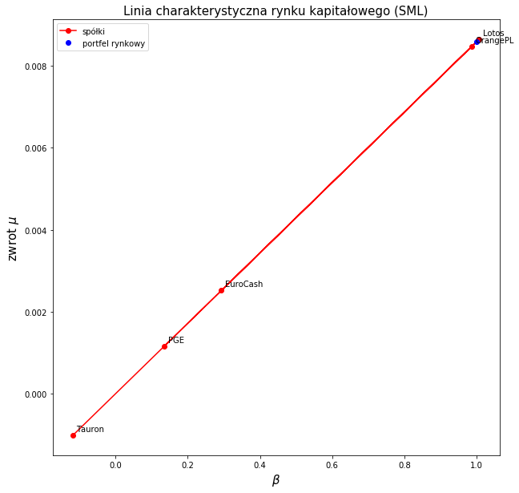

```python
# SML Line

plt.plot([C1/V0, C2/V0, C3/V0, C4/V0, C5/V0], [data1['Returns'].mean(),data2['Returns'].mean(),data3['Returns'].mean(),data4['Returns'].mean(),data5['Returns'].mean()], 'or-')
plt.plot([1], [data0['Returns'].mean()], 'ob')


types = [WIG20[i] for i in reszty]
x_coords = [C1/V0, C2/V0, C3/V0, C4/V0, C5/V0]
y_coords = [data1['Returns'].mean(),data2['Returns'].mean(),data3['Returns'].mean(),data4['Returns'].mean(),data5['Returns'].mean()]
plt.legend(['spółki','portfel rynkowy'])
for i,typ in enumerate(types):
    x = x_coords[i]
    y = y_coords[i]
    plt.text(x+0.01, y+0.0001, typ, fontsize=10)

plt.title('Linia charakterystyczna rynku kapitałowego (SML)', fontsize=15)
plt.xlabel(r'$\beta$', fontsize=15)
plt.ylabel(r'zwrot $\mu$', fontsize=15)
plt.show()
```

# Zadanie 7.

*Dokonać rozkładu ryzyka całkowitego (mierzonego wariancją) na ryzyko dywersyfikowalne i niedywersyfikowalne (systemowe) dla każdej z pięciu spółek*

Ryzyko dla portfela w można rozlożć na dwie skladowe:

$\sigma^2_w = \beta^2_w \sigma^2_m + Var(e_w)$

gdzie:

$\beta_w = \frac{Cov(K_w,K_m)}{\sigma^2_m}$

tym samym:

$\sigma^2_w = \frac{Cov(K_w, K_m)^2}{\sigma^2_m} + Var(e_w)$

Wyliczenia dla poszczególnych spółek:

```python
# ZADANIE 7

B1 = C1/V0
B2 = C2/V0
B3 = C3/V0
B4 = C4/V0
B5 = C5/V0
B_list = [B1, B2, B3, B4, B5]
C_list = [C1, C2, C3, C4, C5]

print(w)

#print(B1**2 * )

# Ryzyko całkowite dla każdej składowej
print()
print("Ryzyko całkowite:")
for i in range(5):
    print(f"Spółka nr: {i+1}: Var_w = {C[i,i]:7.5f}")

# Ryzyko systematyczne
print()
print("Ryzyko systematyczne: ")
for i in range(5):
    print(f'Spółka nr: {i+1}: beta^2 sigma^2_m = {((C_list[i]/V0)**2)*V0:7.5f}')

# Ryzyko dywersyfikowane
print()
print("Ryzyko dywersyfikowalne: ")
for i in range(5):
    print(f"Spółka nr: {i+1}: Var(e_w) = {C[i,i] - (B_list[i]**2)*V0**2:7.5f},   {(B_list[i]**2)*V0**2:7.5f}")
```

```
[[0.12576548]
 [0.10077963]
 [0.23671445]
 [0.33865999]
 [0.19808046]]

Ryzyko całkowite:
Spółka nr: 1: Var_w = 0.00199
Spółka nr: 2: Var_w = 0.00258
Spółka nr: 3: Var_w = 0.00310
Spółka nr: 4: Var_w = 0.00180
Spółka nr: 5: Var_w = 0.00214

Ryzyko systematyczne:
Spółka nr: 1: beta^2 sigma^2_m = 0.00002
Spółka nr: 2: beta^2 sigma^2_m = 0.00107
Spółka nr: 3: beta^2 sigma^2_m = 0.00009
Spółka nr: 4: beta^2 sigma^2_m = 0.00112
Spółka nr: 5: beta^2 sigma^2_m = 0.00002

Ryzyko dywersyfikowalne:
Spółka nr: 1: Var(e_w) = 0.00199,   0.00000
Spółka nr: 2: Var(e_w) = 0.00258,   0.00000
Spółka nr: 3: Var(e_w) = 0.00310,   0.00000
Spółka nr: 4: Var(e_w) = 0.00180,   0.00000
Spółka nr: 5: Var(e_w) = 0.00214,   0.00000
```

# Zadanie 6.

Zakładajac, że r RF = 0% oraz rodzina krzywych obojetności dana jest równaniami postaci $μ − e^σ = const$, wyznaczyć najkorzystniejszy portfel uwzględniający instrument wolny od ryzyka

### (komentarz ) dla skomplikowania, ale również ulatwienia sobie zadania przyjmuję krzywą w postaci ogólnej:

$μ − b\cdot e^{aσ} = c$ gdzie przyjąłem a = 9, b = 0.015, ale oczywiście dla potrzeby zadania mogłybyć równe b = 1, a = 1

Najpierw definiuje funkcję, krzywa obojętności (krzywa_obo). Kolejne kroki postępowania są takie same jak przy rysowaniu krzywej portfeli o najmniejszej wariancji 1 ) Tworze zakres w jakim będzie się zmieniał zwrot.. etc. Na koniec na wykresie zaznaczam krzywe obojętności.

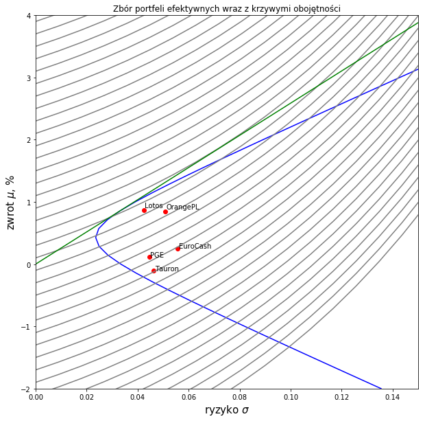

```python
def krzywa_obo(l,c):
     a = 9
     b = 0.015
     return c + b*np.exp(a*l)



m = np.linspace(-0.02, 0.05, 50) # start, stop, ile punktów
g =[]
for i in m:
    lambda_gama = inv(M) * np.matrix([i,1]).T
    w = np.array(lambda_gama[0,:])[0,0] * inv(C) * mu.T + np.array(lambda_gama[1,:])[0,0] * inv(C) * I.T
    g.append( (np.asscalar(w.T*C*w)**0.5))
g = np.array(g)

# simulating a pandas df['type'] column
types = [WIG20[i] for i in reszty]
x_coords = (np.diagonal(C)**0.5)*1
y_coords = (np.array(mu)[0])*100



#μ − b*e**a*σ = const
s=50
k = np.array(np.linspace(0.0, 0.44, s)) # start, stop, ile punktów
l = []



for i,type in enumerate(types):
    x = x_coords[i]
    y = y_coords[i]
    plt.scatter(x, y, marker='o', color='red')
    plt.text(x+x*0.01, y+y*0.05, type, fontsize=10)
plt.plot(g*1, m*100, 'b')

for i in range(s):
    plt.plot(k , 100*krzywa_obo(k,i/500-5/100), '-', color ='gray')
plt.plot([0.0,  5*sig_m], [r,  500*mu_m-r], 'g')
plt.xlim(0, 0.15)
plt.ylim(-2, 4)
plt.title('Zbór portfeli efektywnych wraz z krzywymi obojętności')
plt.xlabel(r'ryzyko $\sigma$', fontsize=15)
plt.ylabel(r'zwrot $\mu$, %', fontsize=15)
plt.show()
```

Rozważając krzywe obojętności zadane równaniem $c = \mu - be^{a\sigma}$ Inwestując w $\lambda$ w portfel rynkowy i $1-\lambda$ w walor wolny od ryzyka możemy uzyskać

$\sigma_{\lambda} = |\lambda| \sigma_m$

$\mu_{\lambda} = (1-\lambda)r+\lambda_{\mu_m}$

gdzie:

$\lambda = \frac{1}{a\sigma_m} ln \frac{\mu_m - r}{ab\sigma_m}$

```python
mu_m = np.asscalar(w2.T*mu.T)
sig_m = np.asscalar(w2.T*C*w2)**0.5

a = 9
b = 0.015
lambdap = np.log((mu_m-r)/a/sig_m/b)/a/sig_m

print("Portfel rynkowy: ", lambdap, "Walor wolny od ryzyka: ", 1-lambdap)
print("Zwrot i ryzyko z optymalnego portfela")
print("Zwrot: ",lambdap*mu_m+(1-lambdap)*r )
print("Ryzyko: ",lambdap*sig_m )
```

```
Portfel rynkowy:  2.176695201348824 Walor wolny od ryzyka:  -1.1766952013488239
Zwrot i ryzyko z optymalnego portfela
Zwrot:  0.018695264338270196
Ryzyko:  0.07226613103859972
```

Pozostaje mi jeszcze zaznaczyć na wykresie umiejscowienie optymalnego portfela.

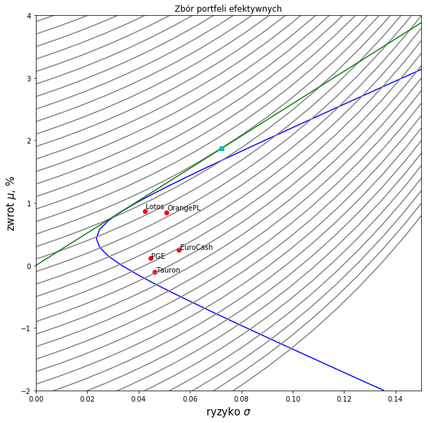

```python
for i,type in enumerate(types):
    x = x_coords[i]
    y = y_coords[i]
    plt.scatter(x, y, marker='o', color='red')
    plt.text(x+x*0.01, y+y*0.05, type, fontsize=10)
plt.plot(g*1, m*100, 'b')

for i in range(s):
    plt.plot(k , 100*krzywa_obo(k,i/500-5/100), '-', color ='gray')
plt.plot([0.0,  5*sig_m], [r,  500*mu_m-r], 'g')
plt.plot(lambdap*sig_m, 100*(lambdap*mu_m+(1-lambdap)*r), 'cs')
plt.xlim(0, 0.15)
plt.ylim(-2, 4)
plt.title('Zbór portfeli efektywnych')
plt.xlabel(r'ryzyko $\sigma$', fontsize=15)
plt.ylabel(r'zwrot $\mu$, %', fontsize=15)
plt.show()
```

# Zadanie 8.

*Wyznaczyć portfel minimalizujący wariancję wśród portfeli o oczekiwanej stopie zwrotu wynoszącej 1%*

Konstrukcja zbioru portfeli efektywnych

$ w = \lambda C^{-1} \mu + \gamma C^{-1} 1, $

$M \begin{bmatrix} \lambda\\ \gamma \end{bmatrix} = \begin{bmatrix} m\\ 1 \end{bmatrix}$

$M = \begin{bmatrix} \mu^T C^{-1}\mu & 1^T C^{-1}\mu \\ \mu^T C^{-1} 1 & 1^T C^{-1} 1 \end{bmatrix} $

$\begin{bmatrix} \lambda\\ \gamma \end{bmatrix} = M^{-1}\begin{bmatrix} m\\ 1 \end{bmatrix}$

Zakłądam: $m = 0.01$

(Generalnie zadanie zawiera się w wyznaczeniu krzywej porfeli o najmniejszej wariancji)

```python
# zwrot
m = 0.01 # start, stop, ile punktów

# ryzyko
g =[]

lambda_gama = inv(M) * np.matrix([m,1]).T
w = np.array(lambda_gama[0,:])[0,0] * inv(C) * mu.T + np.array(lambda_gama[1,:])[0,0] * inv(C) * I.T


print("Liczymy dla zwrotu m = {0:4.2f}".format(m))
print("Macierz M: \n", M)
print("\nMacierz odwrotna M: \n", inv(M))

print()
print("Lambda i gamma:\n",lambda_gama)
print()
print("Wagi dla otrzymanego portfela:\n", w)
print()

# sprawdzam czy dane się zgadzają:
print("Suma wag: ", w.sum())
print("Wariancja portfela: ", w.T*C*w) # variancja portfela
print("mu portfela: ", w.T*mu.T) # mu portfela
```

```
Liczymy dla zwrotu m = 0.01
Macierz M:
 [[6.69258063e-02 7.79219158e+00]
 [7.79219158e+00 1.80223906e+03]]

Macierz odwrotna M:
 [[ 3.00884416e+01 -1.30090900e-01]
 [-1.30090900e-01  1.11732858e-03]]

Lambda i gamma:
 [[ 0.17079352]
 [-0.00018358]]

Wagi dla otrzymanego portfela:
 [[ 0.13377198]
 [ 0.41355778]
 [ 0.07875463]
 [ 0.67509779]
 [-0.30118219]]

Suma wag:  0.9999999999999997
Wariancja portfela:  [[0.00152435]]
mu portfela:  [[0.01]]
```

Dla przypomnienia. Wartość ujemna w wadze oznacza dopuszczenie krótkiej sprzedaży:

Inwestycja polega na sprzedaży akcji której nie posiadamy aby przy spadku cen odkupić ją z zyskiem. W tym celu pożyczamy jedną akcję płacąc jakiś procent jej wartości jako depozyt zabezpieczający, powiedzmy $dS(0)$, gdzie $d ∈ [0, 1]$. Ten depozyt jest jak lokata bankowa, ale ze stopą niższą niż stopa wolna od ryzyka, $0 ≤ R_z ≤ R$. Sprzedajemy pożyczoną akcję inkasując $S(0)$ i lokujemy tą kwotę w obligację ze stopą zwrotu $R$ (w praktyce często kupimy inną akcję). Na koniec odkupujemy akcję płacąc $S(1)$ i odzyskujemy depozyt $dS(0)(1+ R_z )$.